# hwDay3

CNW

1/11/2015

1. Distance from X1=X2=X3=0 to each observation

```
##          [,1]
## [1,] 3.000000
## [2,] 2.000000
## [3,] 3.162278
## [4,] 2.236068
## [5,] 1.414214
## [6,] 3.000000
```

2. With K=1 the conclusion would be Green because the nearest neighbor is observation 5.
3. With K=3 the conclusion would be Green because the nearest neighbors are observations 2, 4, and 5 so the majority decision is Green.
4. The best value for K in a highly non-linear Bayes decision boundary would be a smaller value because it could better account for the variablity in the boundary created. The more sample observations you take into account the more dilluted your decision could become.
9. 1. Quantitative= mpg,cylinders, displacement, horsepower, weight, acceleration, year, origin Qualitative= name

```r
range(Auto$mpg)
```

```
## [1]  9.0 46.6
```

```r
range(Auto$cylinders)
```

```
## [1] 3 8
```

```r
range(Auto$displacement)
```

```
## [1]  68 455
```

```r
range(Auto$horsepower)
```

```
## [1]  46 230
```

```r
range(Auto$weight)
```

```
## [1] 1613 5140
```

```r
range(Auto$acceleration)
```

```
## [1]  8.0 24.8
```

```r
range(Auto$year)
```

```
## [1] 70 82
```

```r
range(Auto$origin)
```

```
## [1] 1 3
```

```
##       mpg          cylinders      displacement     horsepower
##  Min.   : 9.00   Min.   :3.000   Min.   : 68.0   Min.   : 46.0
##  1st Qu.:17.00   1st Qu.:4.000   1st Qu.:105.0   1st Qu.: 75.0
##  Median :22.75   Median :4.000   Median :151.0   Median : 93.5
##  Mean   :23.45   Mean   :5.472   Mean   :194.4   Mean   :104.5
##  3rd Qu.:29.00   3rd Qu.:8.000   3rd Qu.:275.8   3rd Qu.:126.0
##  Max.   :46.60   Max.   :8.000   Max.   :455.0   Max.   :230.0
##
##      weight      acceleration        year           origin
##  Min.   :1613   Min.   : 8.00   Min.   :70.00   Min.   :1.000
##  1st Qu.:2225   1st Qu.:13.78   1st Qu.:73.00   1st Qu.:1.000
##  Median :2804   Median :15.50   Median :76.00   Median :1.000
##  Mean   :2978   Mean   :15.54   Mean   :75.98   Mean   :1.577
##  3rd Qu.:3615   3rd Qu.:17.02   3rd Qu.:79.00   3rd Qu.:2.000
##  Max.   :5140   Max.   :24.80   Max.   :82.00   Max.   :3.000
##
##                  name
##  amc matador       :  5
##  ford pinto        :  5
##  toyota corolla    :  5
##  amc gremlin       :  4
##  amc hornet        :  4
##  chevrolet chevette:  4
##  (Other)           :365
```

```
## [1] 7.805007
```

```
## [1] 1.705783
```

```
## [1] 104.644
```

```
## [1] 38.49116
```

```
## [1] 849.4026
```

```
## [1] 2.758864
```

```
## [1] 3.683737
```

```
##       mpg          cylinders  displacement     horsepower      weight
##  Min.   :14.00   Min.   :8   Min.   :302.0   Min.   :130   Min.   :3433
##  1st Qu.:14.00   1st Qu.:8   1st Qu.:307.0   1st Qu.:150   1st Qu.:3449
##  Median :15.00   Median :8   Median :350.0   Median :165   Median :3693
##  Mean   :15.67   Mean   :8   Mean   :373.2   Mean   :177   Mean   :3883
##  3rd Qu.:17.00   3rd Qu.:8   3rd Qu.:440.0   3rd Qu.:215   3rd Qu.:4341
##  Max.   :18.00   Max.   :8   Max.   :455.0   Max.   :225   Max.   :4425
##
##   acceleration       year        origin                         name
##  Min.   : 8.5   Min.   :70   Min.   :1   amc rebel sst            :1
##  1st Qu.:10.0   1st Qu.:70   1st Qu.:1   buick skylark 320        :1
##  Median :10.5   Median :70   Median :1   chevrolet chevelle malibu:1
##  Mean   :10.5   Mean   :70   Mean   :1   chevrolet impala         :1
##  3rd Qu.:11.5   3rd Qu.:70   3rd Qu.:1   ford galaxie 500         :1
##  Max.   :12.0   Max.   :70   Max.   :1   ford torino              :1
##                                          (Other)                  :3
```

5. Displacement and acceleration appear to have a negative relationship, as displacement increases acceleration decreases.

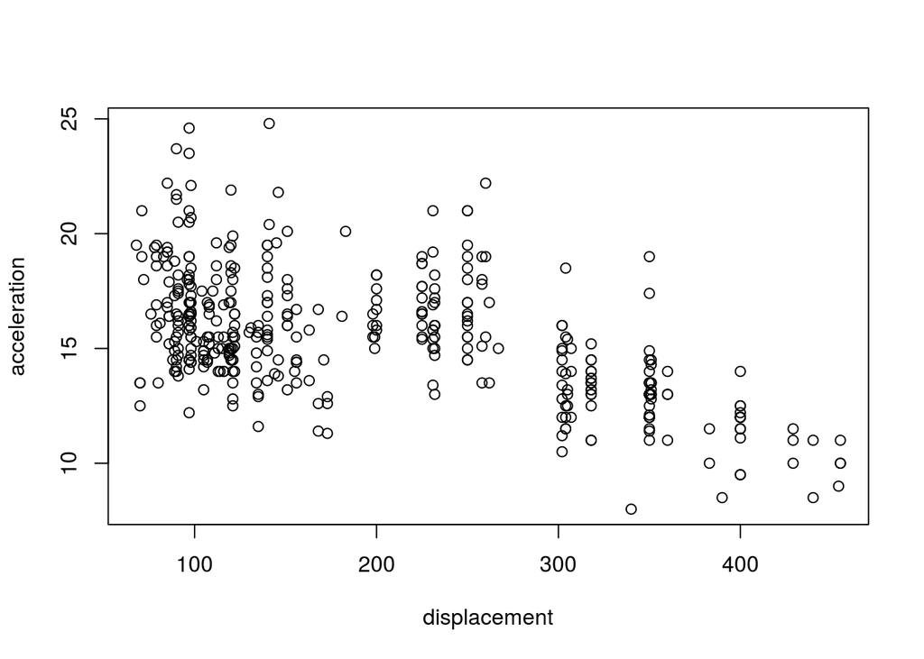

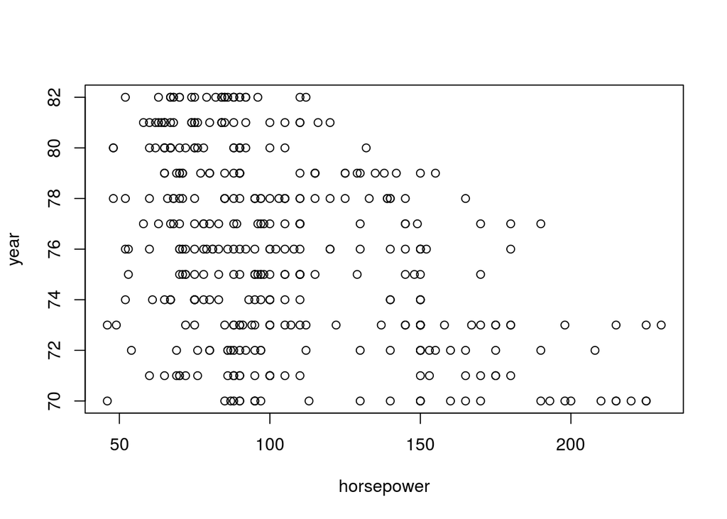

```
## [1] -0.4163615
```

Weight and cylinders seem to have a positive relationship. As weight increases, the number of cylinders increase.

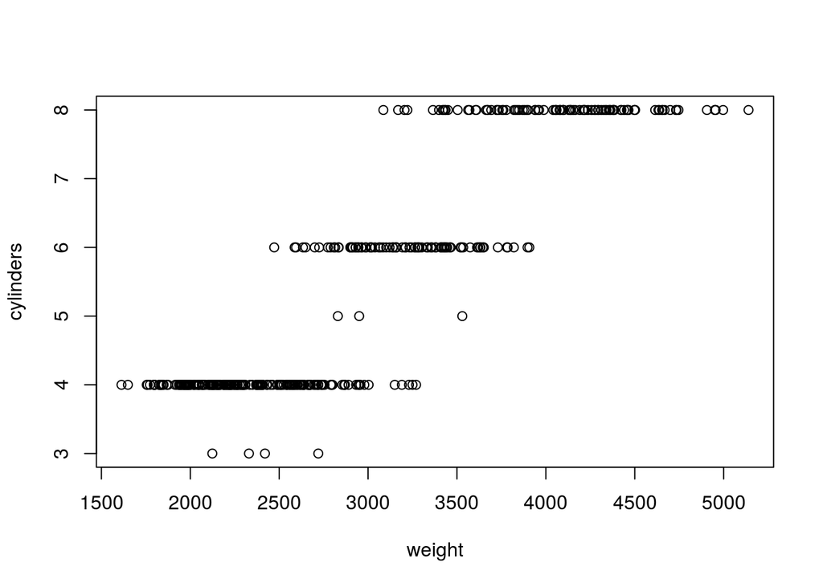

```
## [1] 0.8975273
```

Mpg and year have a fairly moderate positive relationship. As mpg increases the car is probably more recent.

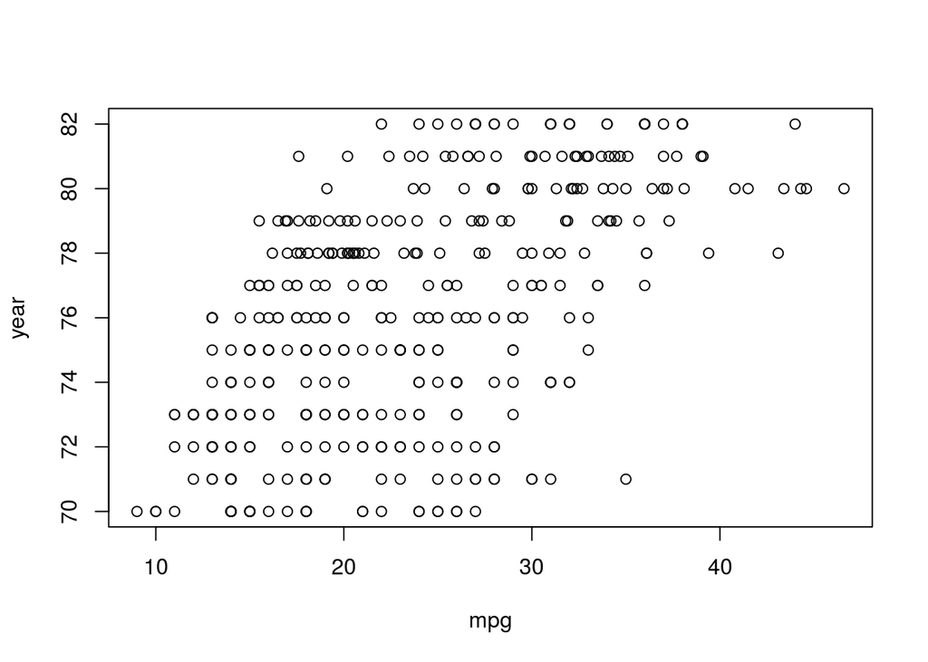

```
## [1] 0.580541
```

6. Horsepower, displacement, and weight seem to be the best predictors of gas mileage. They show the strongest relationships in the plots agains other variables as shown below. Cylinders may also play a role in predicting mpg.

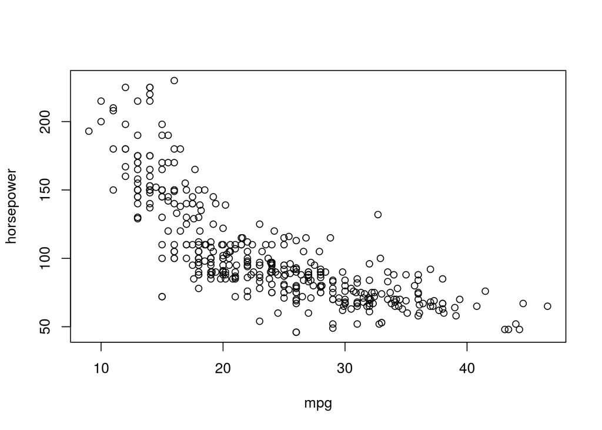

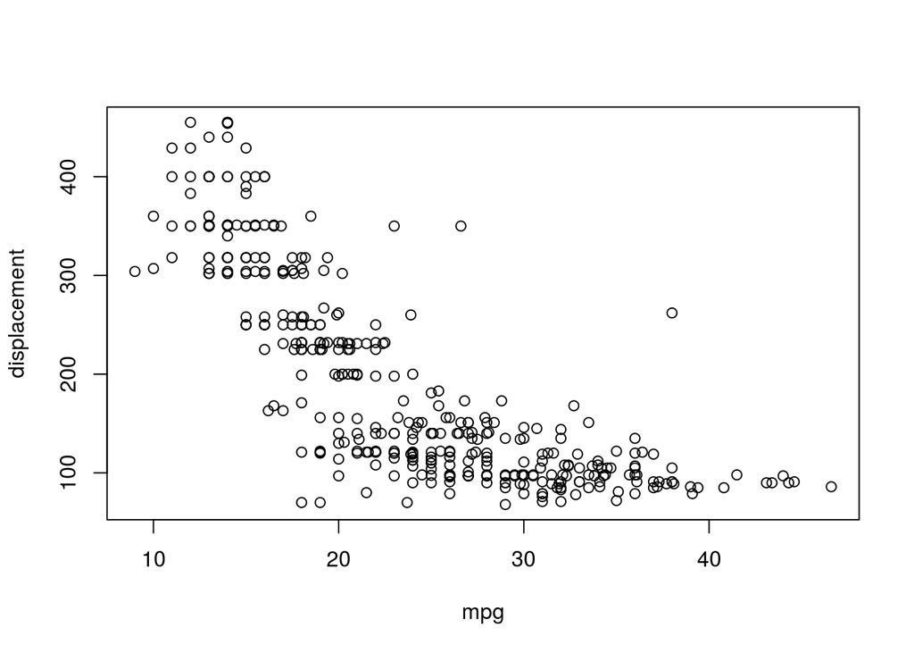

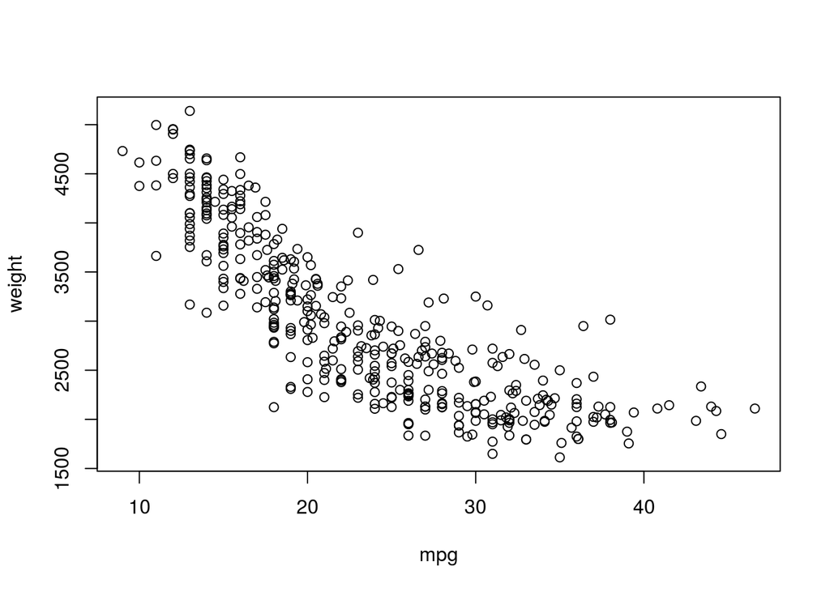

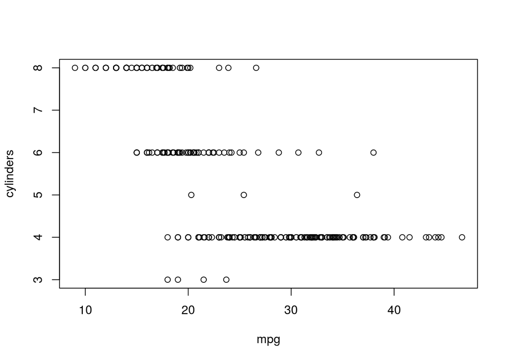

1. There are 506 rows and 14 columns. Columns represent crime rates, residential zones, non-retail business space, Charles River dummy variable, nitrogen oxide concentration, number of rooms per building, proportion of owner-occupied units built before 1940, mean distances to employment centers, accessibility to highways, property tax rate, pupil teacher ratio, proportion of blacks, percent of lower status, median value of owner-occupied homes. The rows represent different suburbs of Boston.

There is a weak negative nonlinear relationship between crime rates and median house value.

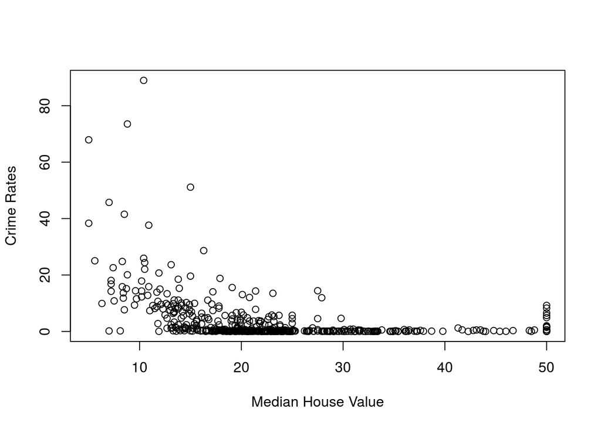

There is no clear relationship between median house value and property tax rates.

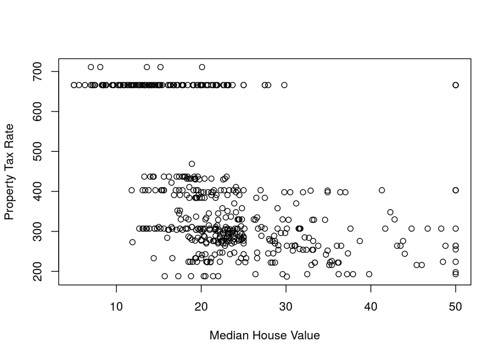

There is a slight negative relationship between non-retail business space and residential zones.

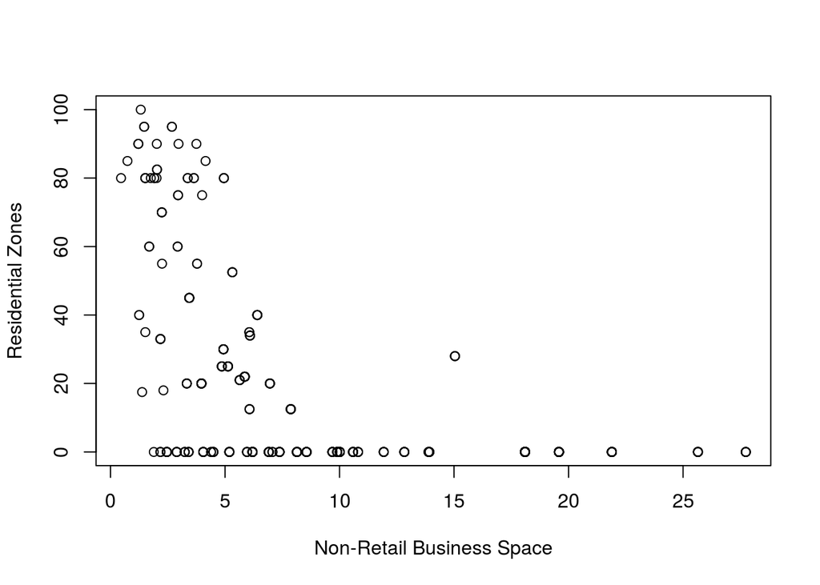

There is no clear relationship between proportion of blacks and percent of lower status.

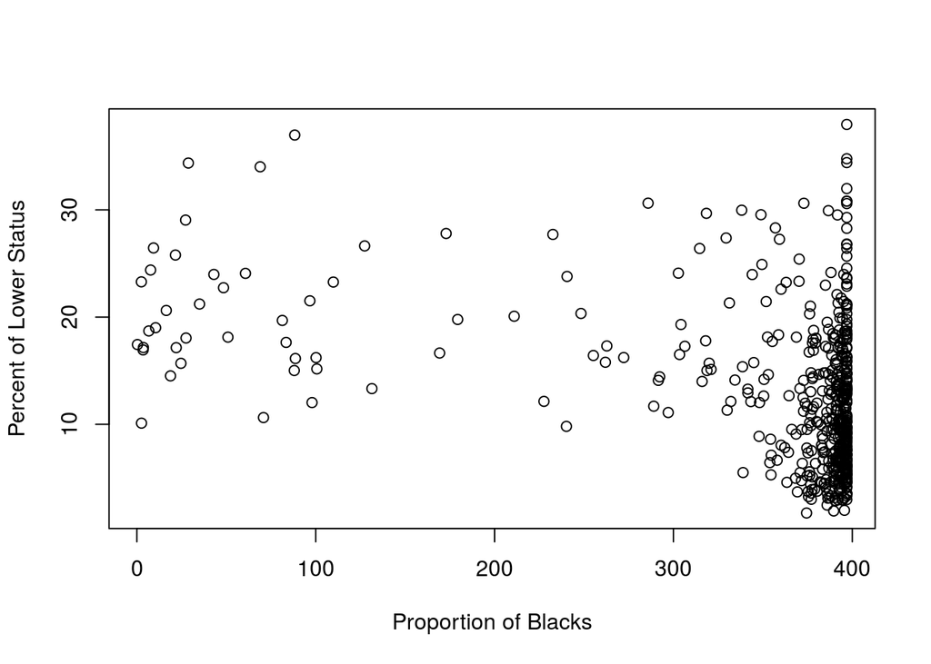

There is a positive nonlinear relationship between nitrogen oxide levels and older houses.

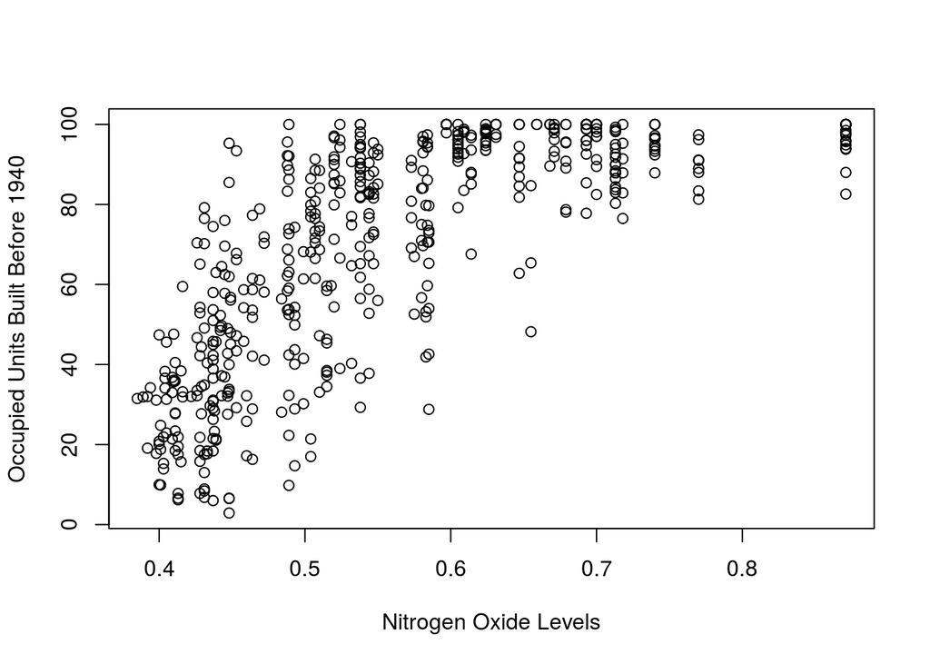

3. There may be some relationship between per capita crime rates and the distance to employment centers. As the distance to these centers decreases crime rates increase.

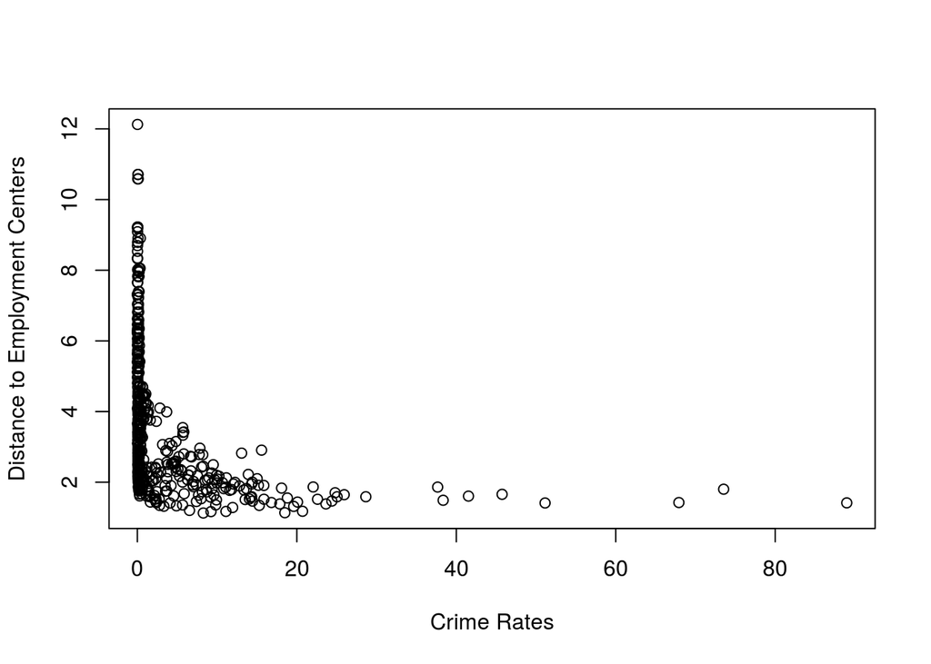

   In relation to median house values, the lower the value the more crime rates increase.

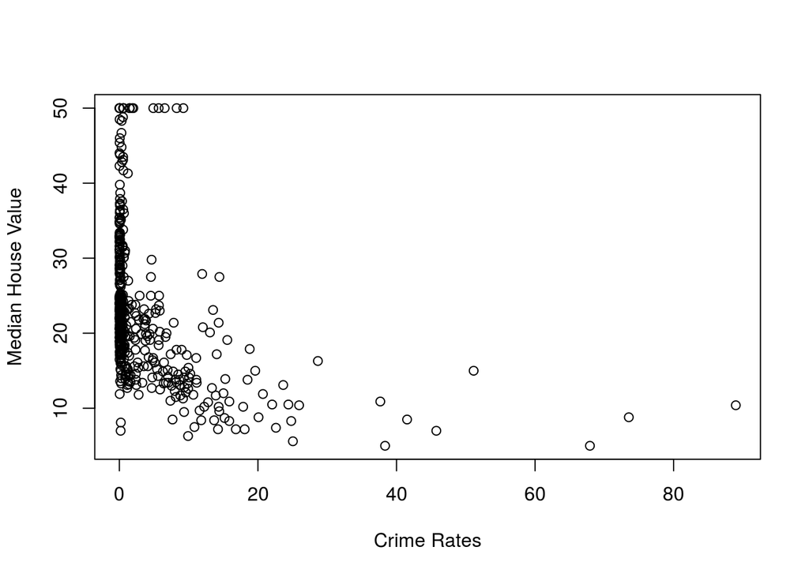

```
## [1]  0.00632 88.97620
```

```
##     Min.  1st Qu.   Median     Mean  3rd Qu.     Max.
##  0.00632  0.08204  0.25650  3.61400  3.67700 88.98000
```

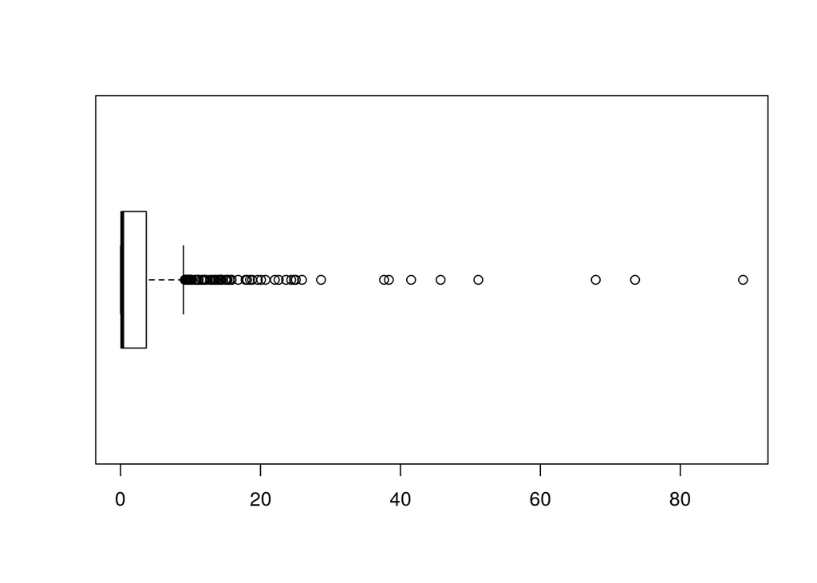

```
## [1] 381 399 405 406 411 415 419 428
```

The range for crime rates is pretty substantial. Given the 3rd Quartile is at 3.677, choosing observations greater than 30 would certainly indicate an abnormally high rate of crime. There are 8 suburbs with crime rates over 30 and they are listed above.

```
## [1] 187 711
```

```
##    Min. 1st Qu.  Median    Mean 3rd Qu.    Max.
##   187.0   279.0   330.0   408.2   666.0   711.0
```

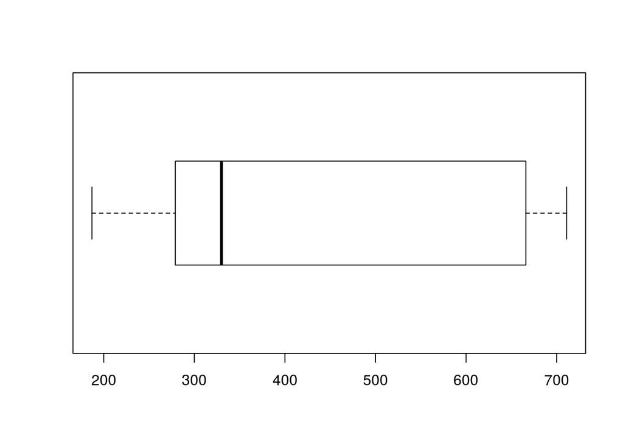

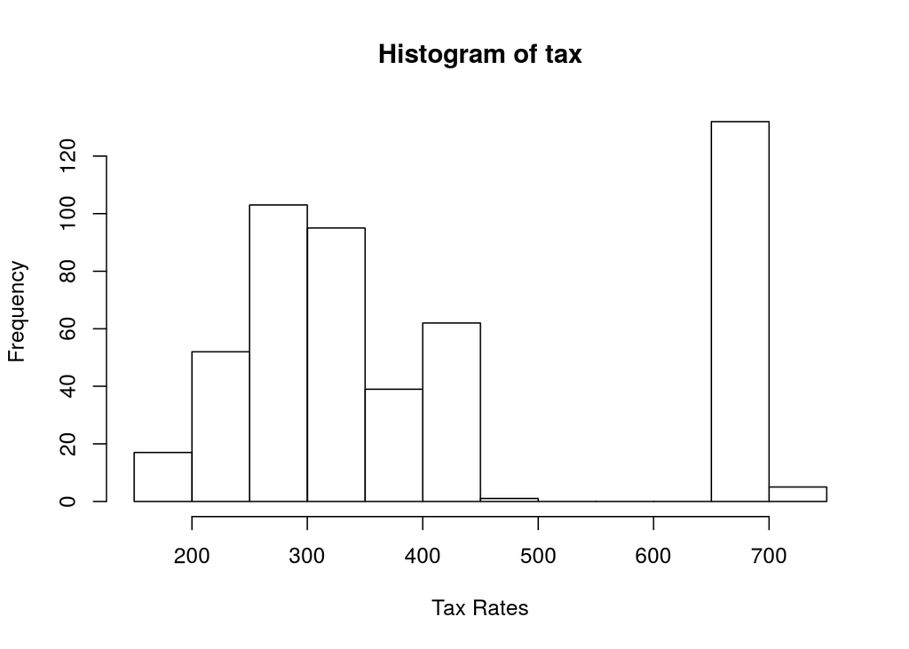

There is a pretty large range for tax rates, and there appears to be quite a few observations that lie well above the mean and median of the data. Over 100 suburbs have tax rates over 650.

```
## [1] 12.6 22.0
```

```
##    Min. 1st Qu.  Median    Mean 3rd Qu.    Max.
##   12.60   17.40   19.05   18.46   20.20   22.00
```

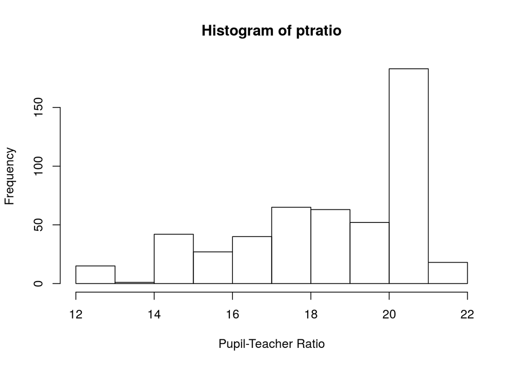

There is not a very large range for pupil-teacher ratio, and there are not many suburbs that are abnormally high.

5. 35 suburbs bound the Charles River, 471 do not.

```
## chas
##   0   1
## 471  35
```

6. The median pupil-teacher ratio is 19.05.

```
##    Min. 1st Qu.  Median    Mean 3rd Qu.    Max.
##   12.60   17.40   19.05   18.46   20.20   22.00
```

7. Suburb 399 has the lowest median house value which is 5.

```
## [1] 5
```

```
## [1] 399
```

8. 64 suburbs average more than 7 rooms per dwelling.

```
## [1] 64
```

13 suburbs average more than 8 rooms per dwelling.

```
## [1] 13
```